# Appendix: Retracing Prenatal Testing Algorithms

Michael Höhle, Stockholm University, Sweden, http://www.math.su.se/~hoehle

2018-06-14

## Abstract

This supplementary material contains the two appendix for the blog post [*Retracing Prenatal Testing Algorithms*](http://math.su.se/~hoehle/blog/2018/06/pcr.html), which contains an implementation of the Merz et al. (2016) method for the risk calculation for Down syndrome based on combined first trimester testing. Appendix 1 contains a detailed description of how the likelihood ratio is computed based on the concept of “degree of extremeness” of an observation. We exemplify this by showing the computations for the NT measurement. Appendix 2 contains an account of our difficulties to reproduce the NT curve given in Fig. 3 of the paper.

This work is licensed under a [Creative Commons Attribution-ShareAlike 4.0 International License](http://creativecommons.org/licenses/by-sa/4.0/). The markdown+Rknitr source code of this blog is available under a [GNU General Public License (GPL v3)](https://www.gnu.org/licenses/gpl-3.0.html) license from github. The specific source file of this appendix is `_drafts/fts-appendix.Rmd`.

## Appendix 1 - Computing the Likelihood Ratios

For each biomarker the likelihood ratio between the euploid and uneuploid population is in Merz et al. (2016), after a possible suitable transformation, computed as a ratio between two Gaussian densities. To this end Merz et al. (2008) introduced the concept of “degree of extremeness” (DoE) of an observation.

### The degree of extremeness of an observation

Let $x$ denote the crown-rump-length (CRL) of a fetus and let $y$ denote the measured biomarker value, say, NT. The DoE is then defined as
$$\operatorname{DoE}(y) = \left\{
\begin{array}{ll}
\displaystyle{\frac{y-\hat{y}(x)}{y^*(x) - \hat{y}(x)}} & \text{if } y \geq \hat{y}(x) \\
\displaystyle{-\frac{\hat{y}(x)-y}{\hat{y}(x) - y_*(x)}} & \text{if } y < \hat{y}(x)
\end{array}
\right.
,$$
where $\hat{y}(x)$ is the predicted value (i.e. the conditional expectation) in a polynomial regression model regressing NT on CRL and $y^*(x)$ and $y_*(x)$ are the so called reference bands from the regression model. These are obtained by subtracting a value $\sigma_*$ from $\hat{y}(x)$ and adding a value $\sigma^*$ to $\hat{y}(x)$ in order to get the 5% and 95% quantiles of the distribution, respectively. Note that this means that the distribution of NT does not have to be symmetric around the mean, but since $\sigma_*$ and $\sigma^*$ are fixed values, the quantiles are assumed to be parallel over the whole range of CRL. There are thus similarities with quantile regression based on a generalized model for location, scale and shape (GAMLSS), which would have been an alternative approach towards the problem and without the discontinuity the $y\leq \hat{y}(x)$ condition gives (Fenske et al. 2008). Since we were unable to obtain any kind of reasonable curve with the 10th order polynomial specified in the upper right column of p. 22 of Merz et al. (2016) (see Appendix 2), we instead inverse graphed the curve from the Fig. 3 of the article using the open-source [Engauge Digitizer](https://markummitchell.github.io/engauge-digitizer/) program.

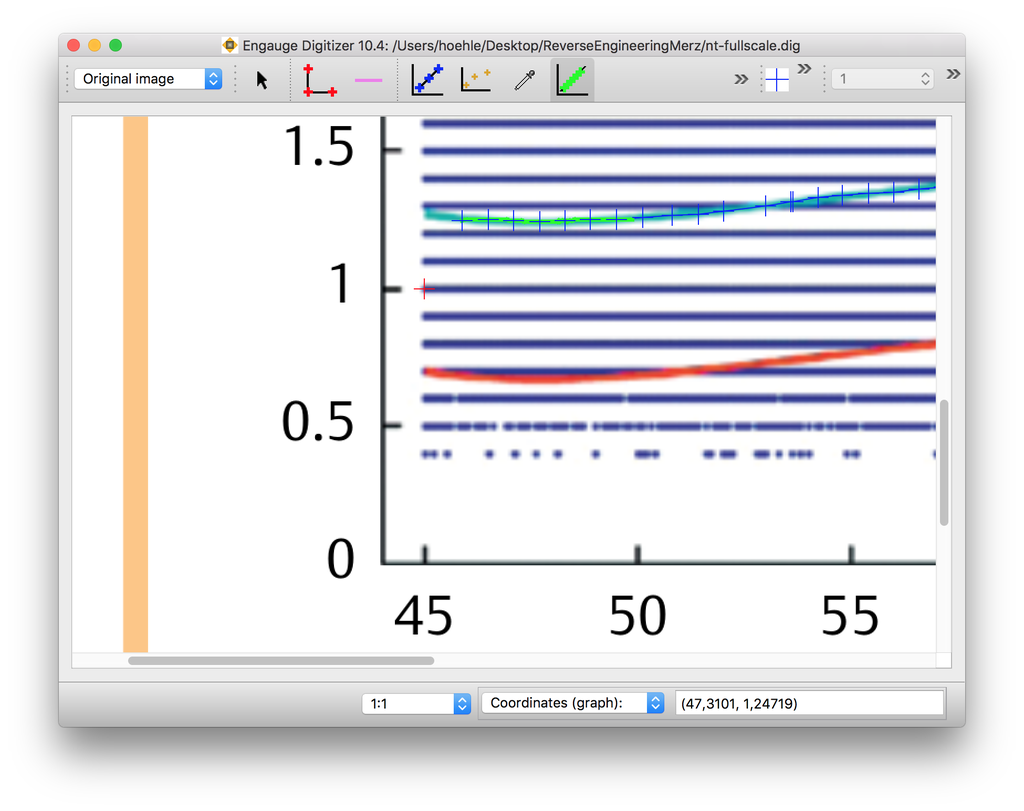

When fitting a 10th order polynomial to the digitized points using least-squares we obtain the following functional form for $\hat{y}(x)$, where $x$ is the CRL (measured in mm).

```r
nt_ls <- function(crl) {
  (86.8495636412728*1) + (-6.45603285194204*crl) + (0.178676863518831*crl^2) + (-0.0019492362713131*crl^3) + (1.25983144232195e-07*crl^5) + (-6.84398153615137e-12*crl^7) + (1.53020537087493e-18*crl^10)
}
```

The functional form can also be illustrated graphically to see how the NT develops with gestational age. Since no data are available to us we can not investigate the uncertainty in the estimated curve, however, polynomials are know to suffer from severe edge effects. A penalized spline might have been a more prudent choice here.

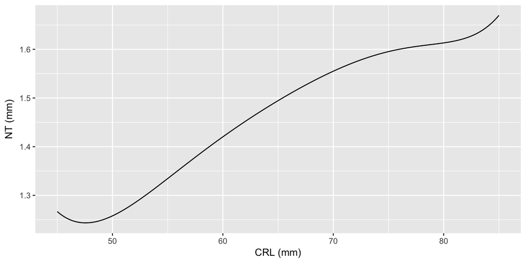

For the calculation of the likelihood ratio it is assumed that the DoEs have an approximate Gaussian distribution with mean and standard deviation depending on a fetus’ ploidy. Reversing the $DoE(y)$ formula while treating all values besides $y$ as fixed, yields

$$y = \left\{
\begin{array}{ll}
DOE \cdot (y^*(x) - \hat{y}(x)) + \hat{y}(x) & \text{if } y \geq \hat{y}(x) \\
DOE \cdot (\hat{y}(x) - y_*(x)) + \hat{y}(x) & \text{if } y < \hat{y}(x)
\end{array}
\right.$$
where $DOE \sim N(\mu, \sigma^2)$ with mean and variance depending on the ploidy. For NT, an additional $\sqrt[7]{DOE+2.5}$ transformation to normality is performed, i.e. $\sqrt[7]{DOE+2.5} \sim N(\mu, \sigma^2)$. In Merz et al. (2016) the parameters of these two Gaussian distributions are estimated from data and stated to be
$$\begin{align*}
\mu_{\text{eu}} = 1.13263 && \sigma_{\text{eu}} = 0.04320 \\
\mu_{\text{aneu}} = 1.23730 && \sigma_{\text{aneu}} = 0.09251 \\
\end{align*}$$
In other words, higher NT values are indicative of T21. Unfortunately, the Merz et al. (2016) paper only shows the raw NT data for the $n = 186,215$ euploid pregnancies (Fig. 3) so it’s hard to assess how adequate these distributional assumption for the T21 aneuploid population is. In Merz et al. (2011) a T21 population of $n=500$ fetus is mentioned, but not graphed. Looking at Fig. 9 of Nicolaides (2004) or Fig. 1 of Kagan et al. (2008) it becomes obvious that the distinction between the two populations based on NT measurements is limited to the range of 40-75 mm crown-rump-length. The larger the fetus is at the scan (i.e. the later it is scanned), the less clear cut the distinction between the two populations appears and the greater the uncertainty of any statement will - also because of the smaller number of measurements at CRLs of 80-85 mm. This is not reflected by the above formulas, but without the T21 data it is hard to assess, if this is also a problem for the analysis in Merz et al. (2016).

Altogether, the likelihood ratio for a NT measurement of 2.3 mm at a CRL of 57.7 mm of is computed as follows:

```r
## Bandwidths, see Merz et al. (2016) paper
nt_qBands <-      c(-0.57159, 0.65869)

## Gestational age. Although not said Tab. 5 in Merz et al. (2016) is measured
## in weeks, but the graph & formula expect the crl to be in mm.
## We take the conversion formula from http://journals.sagepub.com/doi/pdf/10.1179/174313409X448543
##
## Gestational age = (CRL x 1.037)^0.5 x 8.052 + 23.73
crl <- gestage2crl(86)

##Measurement, predictions and lower/upper band
y <- c(nt=2.3)
y_pred <- c(nt=nt_ls(crl))
y_ref <- c(y_pred + nt_qBands[1], y_pred + nt_qBands[2])

##Compute degree of extremeness for the NT measurement
(doe_nt <- doe( y, y_pred, y_ref[1], y_ref[2]))
```

```
##       nt
## 1.394691
```

```r
##NT values from Table 3 of Merz et al. (2016)
eu   <- c(mean=1.13263, sd=0.0432)
aneu <- c(mean=1.23730, sd=0.09251)

##Compute likelihood ratios - values from Merz et al. (2016)
(lr_nt <- lr( (doe_nt + 2.5)^(1/7), eu=eu,  aneu=aneu))
```

```
## [1] 2.713327
```

In other words, the observed NT value is indicative for T21, because $\operatorname{LR}_{\text{NT}}>1$. If NT would be the only biomarker measured it would take one from an prior odds of $1:145$ to a posterior odds of $1:(0.37\cdot 145)=1:53$.

In the above computation `lr` is a function to compute the ratio between two Gaussian densities:

```r
# Likelihood ratio between two univariate normals
#
# @param x measured value
# @param eu eucaryte (i.e. value in non-diseased population)
# @param aneu anormal eucaryte (i.e. value in diseased population)
# @return dnorm(x, mean=aneu[1], sd=aneu[2]) / dnorm(x, mean=eu[1], sd=eu[2])

lr <- function(x, eu, aneu) {
  eu[2] / aneu[2] * exp(-0.5*((x-aneu[1])/aneu[2])^2 + 0.5*((x-eu[1])/eu[2])^2)
}
```

As an alternative to the pure quantitative risk calculation, the DoE for each of the three observed biomarkers can also be visualized. From the above formula we use the transformation of probabilities theorem to derive the distribution of $y$ in the euploid an aneuploid population, respectively. These densities are then plotted against each other. Note the discontinuity at an observed NT value of $y = \hat{y}(x)=1.4$ mm.

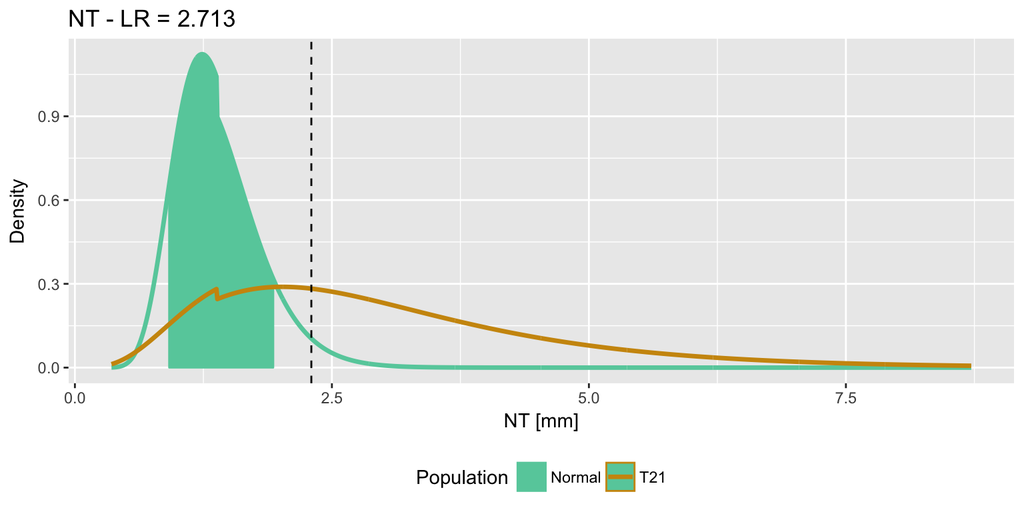

## Appendix 2 - The NT Polynomial stated in Merz et al. (2016)

The polynomial formula described in Merz et al. (2016) as characterising “the dependence of the mean of that variable on gestational age as expressed in terms of CRL” is given in the top right-hand column of p. E22:

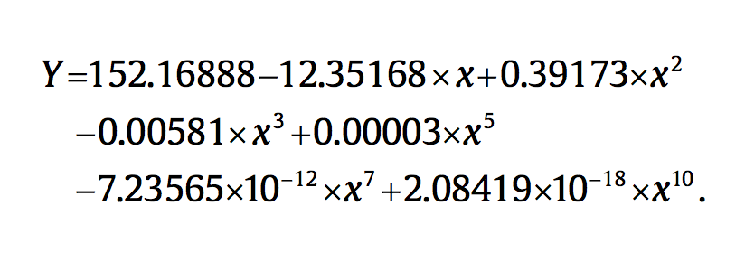

However, using $x$ as CRL (measured in mm) provides no way near results corresponding to what is shown in Fig. 3 of the paper (we even checked against accidentally flipped signs).

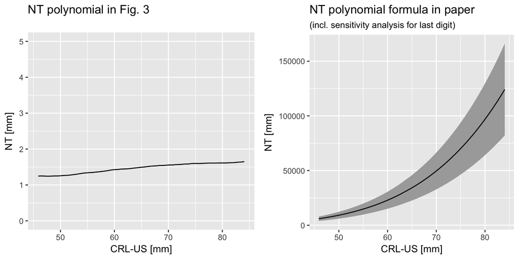

We first suspected this discrepancy due to the reported polynomial being rounded to five “significant digits”" - see e.g. the $x^5$ term of the polynomial - and contacted the authors about this. The reply was that further digits could not be provided, because a commercial software company holds the right to the algorithm. Based on this answer we conducted a sensitivity analysis trying the smallest and largest possible value yielding the same reported significant digits for each of the 7 terms of the polynomial. The bands in the right hand figure show the smallest and largest possible value of these $3^7=2187$ combinations. Based on this figure it becomes clear that rounding is not the problem. Either

1. some sort of transformation (e.g. between gestational age in weeks and CRL in mm) or
2. a, later in the paper described 7th-square-root transformation
3. or some other non-documented transformation

is additionally applied to $x$ or $y$. We contacted the authors again with this finding asking them about which of the above applies, but unfortunately they either lacked the time to reply or chose not to reply. At least we never heard back. From a **scientific point of view** we find the excuse of a third-party-copyright-holder preventing transparency of the algorithm very disappointing. As a consequence, we inverse graphed the polynomial from Fig. 3 and became motivated to write a ShinyAapp reproducing the computations, because algorithms on such sensitive matters should be **transparent** and **reproducible**!

## References

Fenske, N., L. Fahrmeir, P. Rzehak, and M. Höhle. 2008. “Detection of Risk Factors for Obesity in Early Childhood with Quantile Regression Methods for Longitudinal Data.” Department of Statistics, University of Munich, Germany. https://epub.ub.uni-muenchen.de/6260/1/TechRepFenskeetal.pdf.

Kagan, K. O., D. Wright, A. Baker, D. Sahota, and K. H. Nicolaides. 2008. “Screening for trisomy 21 by maternal age, fetal nuchal translucency thickness, free beta-human chorionic gonadotropin and pregnancy-associated plasma protein-A.” *Ultrasound Obstet Gynecol* 31 (6): 618–24.

Merz, E., C. Thode, A. Alkier, B. J. Hackelöer, M. Hansmann, G. Huesgen, P. Kozlowski, M. Pruggmaier, and S. Wellek. 2008. “A New Approach to Calculating the Risk of Chromoso- Mal Abnormalities with First-Trimester Screening Data.” *Ultraschall in Der Medizin / European Journal of Ultrasound* 29: 639–45. doi:10.1055/s-2008-1027958.

Merz, E., C. Thode, B. Eiben, and S. Wellek. 2016. “Prenatal Risk Calculation (PRC) 3.0: An Extended Doe-Based First-Trimester Screening Algorithm Allowing for Early Blood Sampling.” *Ultrasound International Open* 2: E19–E26. doi:10.1055/s-0035-1569403.

Merz, E., C. Thode, B. Eiben, R. Faber, B. J. Hackelöer, G. Huesgen, M. Pruggmaier, and S. Wellek. 2011. “Individualized Correction for Maternal Weight in Calculating the Risk of Chromosomal Abnormalities with First-Trimester Screening Data.” *Ultraschall in Der Medizin/European Journal of Ultrasound* 32: 33–39. doi:http://dx.doi.org/10.1055/.

Nicolaides, K. H. 2004. *The 11–13$^{+6}$ Weeks Scan*. Fetal Medicine Foundation, https://fetalmedicine.com/synced/fmf/FMF-English.pdf.